# PSTAT 131 Project

Leonel Carlen / Stefan Ciric

12/11/2019

# 1.

# What makes voter behavior prediction (and thus election forecasting) a hard problem?

The sheer number of unpredictable factors that affect any one person’s personal politicization in modern society makes it hard to predict Voter behavior. The fact, that there’s more than two candidates and parties makes the classificationtask even harder. Another reason could be differential voter turnout; 2016’s polls were based on the assumption that relatively equal numbers of Democrats and Republicans would vote, but in reality there was a significantly higher republican voter turnout than Democratic voter turnout. Another reason could be that there were last minute changes in voter decisions; post-election polls found that many voters changed their vote in the week leading up to the election. Moreover, there are things that affect voting behaviors that aren’t necessarily quantifiable, for example, a particularly successful campaign ad! In the Guardian Article, Bob O’Hara calls these occurrences “shocks”. One more big problem, is the idea of polling data and how reliable it is. Alot of times pollsters might be biased or the population of people that take the exit polls may not be representative of the actual voter population, or they might even lie.

# 2.

# What was unique to Nate Silver’s approach in 2012 that allowed him to achieve good predictions?

Usually, the outcome with the maximum probability is taken to be the most likely outcome. Silver’s approach was to look at a full range of probabilities rather than just the maximum probability. In the election setting, for example, he calculated a range of probabilities of support for different dates. For the following date, he could use the model for actual support to predict the probability that support has shifted from one number to another; then if the actual polling numbers are higher for example, the probability of support is likely to be in the higher end of the range. This prediction model is based on the Bayes’ Theorem.

# 3.

# What went wrong in 2016? What do you think should be done to make future predictions better?

In 2016, the candidates were extremely controversial, and thus made it really hard to predict the outcome of the votes accurately. News and current events played a huge part in swaying voters during this election.Many voters made last minute decision changes, causing most predictions to be wrong. To make future predictions more accurate, voter demographic information should be taken into account at a federal, state, and county level and supervised learning models should be applied to better predict which factors are most influential in voter choice, and categorize voters into candidate groups.

# 4.

Every row with a county value of ‘NA’ is a summary row. A row is a federal-level summary row if it has a flip value of ‘US’ and it is a state-level summary row if it has a state name as fips value. We remove remove with the fips value of 2000 due to the fact, that they are duplicates of the state-level summary rows with the fips value of ‘AK’. We then reference the list of 2016 fips values and confirm that our dataset contains no more duplicates such as this one and continue our analysis. The dimensions before removing were 18351 and after removing 18345.

| county | fips | candidate | state | votes |
| --- | --- | --- | --- | --- |
| NA | 2000 | Donald Trump | AK | 163387 |
| NA | 2000 | Hillary Clinton | AK | 116454 |
| NA | 2000 | Gary Johnson | AK | 18725 |
| NA | 2000 | Jill Stein | AK | 5735 |
| NA | 2000 | Darrell Castle | AK | 3866 |
| NA | 2000 | Rocky De La Fuente | AK | 1240 |

# 5.

```
## [1] 32
```

```
## [1] 302
```

```
## [1] 18015
```

Federal-level, State-level, and county summary-rows are filtered.

Federal

| county | fips | candidate | state | votes |
| --- | --- | --- | --- | --- |
| NA | US | Donald Trump | US | 62984825 |
| NA | US | Hillary Clinton | US | 65853516 |
| NA | US | Gary Johnson | US | 4489221 |
| NA | US | Jill Stein | US | 1429596 |
| NA | US | Evan McMullin | US | 510002 |
| NA | US | Darrell Castle | US | 186545 |

State

| county | fips | candidate | state | votes |
| --- | --- | --- | --- | --- |
| NA | CA | Hillary Clinton | CA | 8753788 |
| NA | CA | Donald Trump | CA | 4483810 |
| NA | CA | Gary Johnson | CA | 478500 |
| NA | CA | Jill Stein | CA | 278657 |
| NA | CA | Gloria La Riva | CA | 66101 |
| NA | FL | Donald Trump | FL | 4617886 |

County

| county | fips | candidate | state | votes |
| --- | --- | --- | --- | --- |
| Los Angeles County | 6037 | Hillary Clinton | CA | 2464364 |
| Los Angeles County | 6037 | Donald Trump | CA | 769743 |
| Los Angeles County | 6037 | Gary Johnson | CA | 88968 |
| Los Angeles County | 6037 | Jill Stein | CA | 76465 |
| Los Angeles County | 6037 | Gloria La Riva | CA | 21993 |
| Cook County | 17031 | Hillary Clinton | IL | 1611946 |

# 6.

```
## [1] 32
```

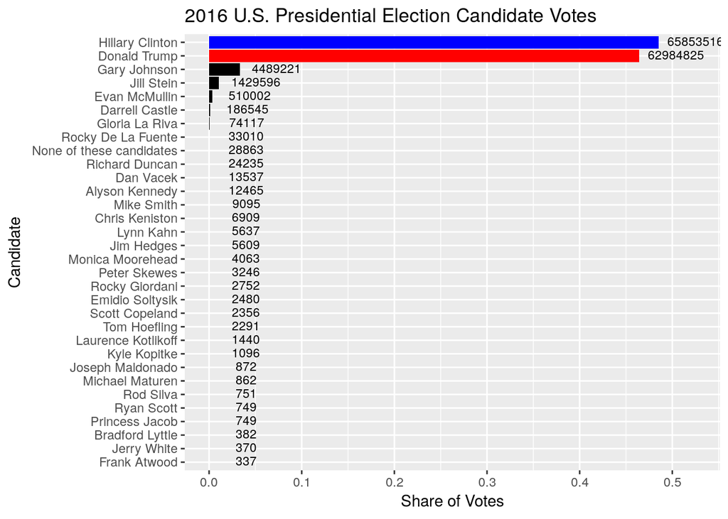

In the 2016 election, there were 32 presidential candidates.

# 7.

Winner for County

| county | fips | candidate | state | votes | total | pct |
| --- | --- | --- | --- | --- | --- | --- |
| Los Angeles County | 6037 | Hillary Clinton | CA | 2464364 | 3421533 | 0.7202514 |
| Cook County | 17031 | Hillary Clinton | IL | 1611946 | 2156395 | 0.7475189 |
| Maricopa County | 4013 | Donald Trump | AZ | 747361 | 1536743 | 0.4863279 |
| Harris County | 48201 | Hillary Clinton | TX | 707914 | 1305434 | 0.5422825 |
| San Diego County | 6073 | Hillary Clinton | CA | 735476 | 1291078 | 0.5696604 |
| Orange County | 6059 | Hillary Clinton | CA | 609961 | 1186203 | 0.5142130 |

Winner for State

| county | fips | candidate | state | votes | total | pct |
| --- | --- | --- | --- | --- | --- | --- |
| NA | CA | Hillary Clinton | CA | 8753788 | 14060856 | 0.6225644 |
| NA | FL | Donald Trump | FL | 4617886 | 9419886 | 0.4902274 |
| NA | TX | Donald Trump | TX | 4685047 | 8917965 | 0.5253493 |
| NA | NY | Hillary Clinton | NY | 4556124 | 7660190 | 0.5947795 |
| NA | PA | Donald Trump | PA | 2970733 | 6115402 | 0.4857789 |
| NA | IL | Hillary Clinton | IL | 3090729 | 5523142 | 0.5595962 |

Hillary Clinton was the state-winner in California while Trump won Florida. She also was the county winner in Los Angeles County due to the highest portion of votes. Trump won Maricopa County.

# 8.

County-level map of the United States colored by county.

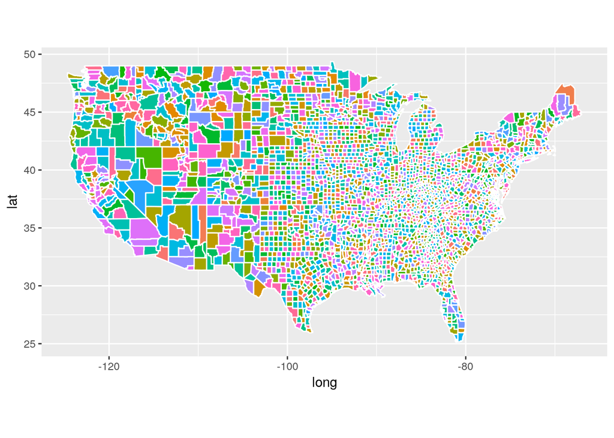

# 9.

Map of the United States colored by the winning candidate for each state.

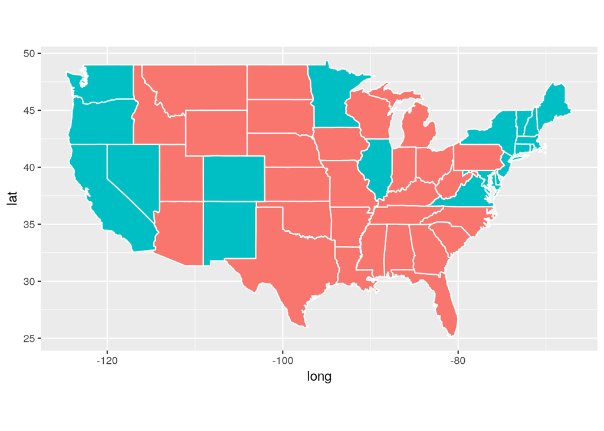

#10. Map United States colored by the winning candidate by county.

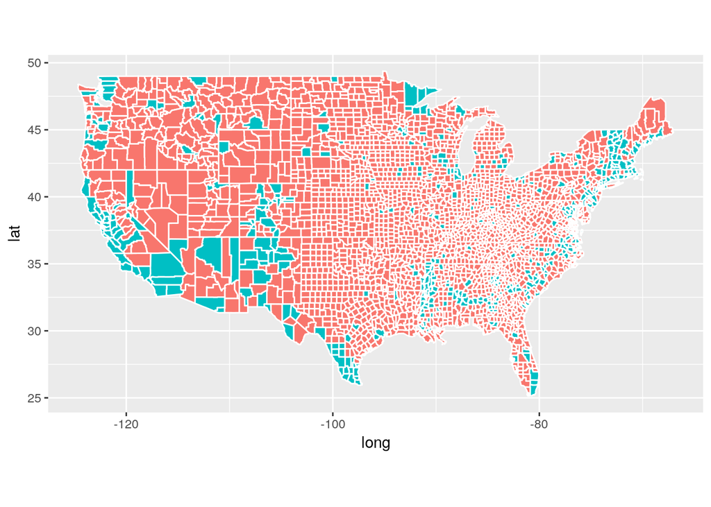

# 11.

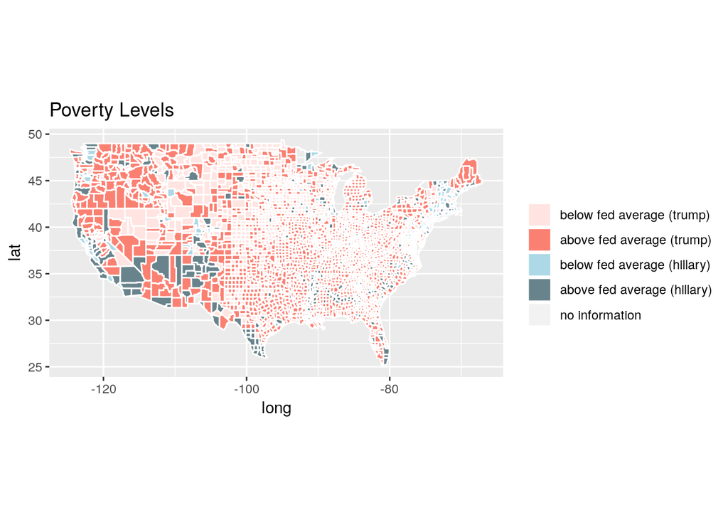

#12.

County Census Data

| State | County | Men | Women | White | Citizen | Minority | Income | IncomeErr | IncomePerCap | IncomePerCapErr | Poverty | ChildPoverty | Professional | Service | Office | Production | Drive | Carpool | Transit | OtherTransp | WorkAtHome | MeanCommute | Employed | PrivateWork | SelfEmployed | FamilyWork | Unemployment | CountyTotal |
| --- | --- | --- | --- | --- | --- | --- | --- | --- | --- | --- | --- | --- | --- | --- | --- | --- | --- | --- | --- | --- | --- | --- | --- | --- | --- | --- | --- | --- |
| Alabama | Autauga | 48.43266 | 3348.805 | 75.78823 | 73.74912 | 22.53687 | 51696.29 | 7771.009 | 24974.50 | 3433.674 | 12.91231 | 18.70758 | 32.79097 | 17.17044 | 24.28243 | 17.15713 | 87.50624 | 8.781235 | 0.0952590 | 1.3059687 | 1.8356531 | 26.50016 | 43.43637 | 73.73649 | 5.433254 | 0.0000000 | 7.733726 | 12 |
| Alabama | Baldwin | 48.84866 | 3934.167 | 83.10262 | 75.69406 | 15.21426 | 51074.36 | 8745.050 | 27316.84 | 3803.718 | 13.42423 | 19.48431 | 32.72994 | 17.95092 | 27.10439 | 11.32186 | 84.59861 | 8.959078 | 0.1266209 | 1.4438000 | 3.8504774 | 26.32218 | 44.05113 | 81.28266 | 5.909353 | 0.3633269 | 7.589820 | 31 |
| Alabama | Barbour | 53.82816 | 1491.941 | 46.23159 | 76.91222 | 51.94382 | 32959.30 | 6031.065 | 16824.22 | 2430.189 | 26.50563 | 43.55962 | 26.12404 | 16.46343 | 23.27878 | 23.31741 | 83.33021 | 11.056609 | 0.4954032 | 1.6217251 | 1.5019456 | 24.51828 | 31.92113 | 71.59426 | 7.149837 | 0.0897742 | 17.525557 | 9 |
| Alabama | Bibb | 53.41090 | 2930.106 | 74.49989 | 77.39781 | 24.16597 | 38886.63 | 5662.358 | 18430.99 | 3073.599 | 16.60375 | 27.19708 | 21.59010 | 17.95545 | 17.46731 | 23.74415 | 83.43488 | 13.153641 | 0.5031366 | 1.5620952 | 0.7314679 | 28.71439 | 36.69262 | 76.74385 | 6.637936 | 0.3941515 | 8.163104 | 4 |
| Alabama | Blount | 49.40565 | 3562.081 | 87.85385 | 73.37550 | 10.59474 | 46237.97 | 8695.786 | 20532.27 | 2052.055 | 16.72152 | 26.85738 | 28.52930 | 13.94252 | 23.83692 | 20.10413 | 84.85031 | 11.279222 | 0.3626321 | 0.4199411 | 2.2654133 | 34.84489 | 38.44914 | 81.82671 | 4.228716 | 0.3564928 | 7.699640 | 9 |
| Alabama | Bullock | 53.00618 | 1968.034 | 22.19918 | 75.45420 | 76.53587 | 33292.69 | 9000.345 | 17579.57 | 3110.645 | 24.50260 | 37.29116 | 19.55253 | 14.92420 | 20.17051 | 25.73547 | 74.77277 | 14.839127 | 0.7732160 | 1.8238247 | 3.0998783 | 28.63106 | 36.19592 | 79.09065 | 5.273684 | 0.0000000 | 17.890026 | 3 |

The table shows census data containing high resolution information. The information was aggregated into county level data after computing the total population-weighted average of each attribute for each county. #13.

```
##  [1] "State"           "County"          "Men"
##  [4] "Women"           "White"           "Citizen"
##  [7] "Minority"        "Income"          "IncomeErr"
## [10] "IncomePerCap"    "IncomePerCapErr" "Poverty"
## [13] "ChildPoverty"    "Professional"    "Service"
## [16] "Office"          "Production"      "Drive"
## [19] "Carpool"         "Transit"         "OtherTransp"
## [22] "WorkAtHome"      "MeanCommute"     "Employed"
## [25] "PrivateWork"     "SelfEmployed"    "FamilyWork"
## [28] "Unemployment"    "CountyTotal"
```

```
##           State          County             Men           Women
##              NA              NA    5.416023e+00    5.794646e+05
##           White         Citizen        Minority          Income
##    5.264985e+02    2.782521e+01    5.265263e+02    1.871915e+08
##       IncomeErr    IncomePerCap IncomePerCapErr         Poverty
##    5.807218e+06    3.804072e+07    1.210144e+06    6.931216e+01
##    ChildPoverty    Professional         Service          Office
##    1.317339e+02    3.993572e+01    1.360058e+01    1.022755e+01
##      Production           Drive         Carpool         Transit
##    3.300854e+01    5.737029e+01    8.508591e+00    9.442292e+00
##     OtherTransp      WorkAtHome     MeanCommute        Employed
##    2.920815e+00    9.714816e+00    3.115353e+01    4.796921e+01
##     PrivateWork    SelfEmployed      FamilyWork    Unemployment
##    6.274646e+01    1.531612e+01    1.983356e-01    1.707899e+01
##     CountyTotal
##    5.158019e+03
```

```
## [1] "IncomePerCap" "ChildPoverty" "Poverty"
```

```
## [1] "IncomePerCap" "Professional" "Poverty"
```

```
##  [1] "IncomePerCap"    "Professional"    "Poverty"
##  [4] "Income"          "ChildPoverty"    "Service"
##  [7] "Unemployment"    "Minority"        "White"
## [10] "Employed"        "IncomePerCapErr" "Production"
## [13] "IncomeErr"       "WorkAtHome"      "Carpool"
## [16] "Citizen"         "Drive"           "SelfEmployed"
## [19] "Transit"         "OtherTransp"     "PrivateWork"
## [22] "Women"           "CountyTotal"     "Men"
## [25] "CountyWeight"    "FamilyWork"      "Office"
## [28] "MeanCommute"
```

|  | PC1 | PC2 |
| --- | --- | --- |
| IncomePerCap | 1 | 1 |
| Professional | 1 | 1 |
| Poverty | -1 | 1 |
| Income | 1 | 1 |
| ChildPoverty | -1 | 1 |
| Service | -1 | 1 |
| Unemployment | -1 | 1 |
| Minority | -1 | 1 |
| White | 1 | -1 |
| Employed | 1 | 1 |

[output cut: 18 more lines]

```
##  [1] "Poverty"      "ChildPoverty" "Service"      "Unemployment"
##  [5] "Minority"     "Production"   "Carpool"      "Transit"
##  [9] "OtherTransp"  "PrivateWork"  "CountyTotal"  "CountyWeight"
## [13] "Office"
```

```
## [1] "White"        "Production"   "Carpool"      "Citizen"
## [5] "Drive"        "Men"          "CountyWeight" "FamilyWork"
## [9] "Office"
```

We scaled it before we used it due to the fact, that every attribute has a different scale. The largest absolute values were IncomePerCap, Professional and Poverty. White, Production, Carpool, Citizen, Drive, Men, FamilyWork, Office, Weight have a significant correlation .

# 14.

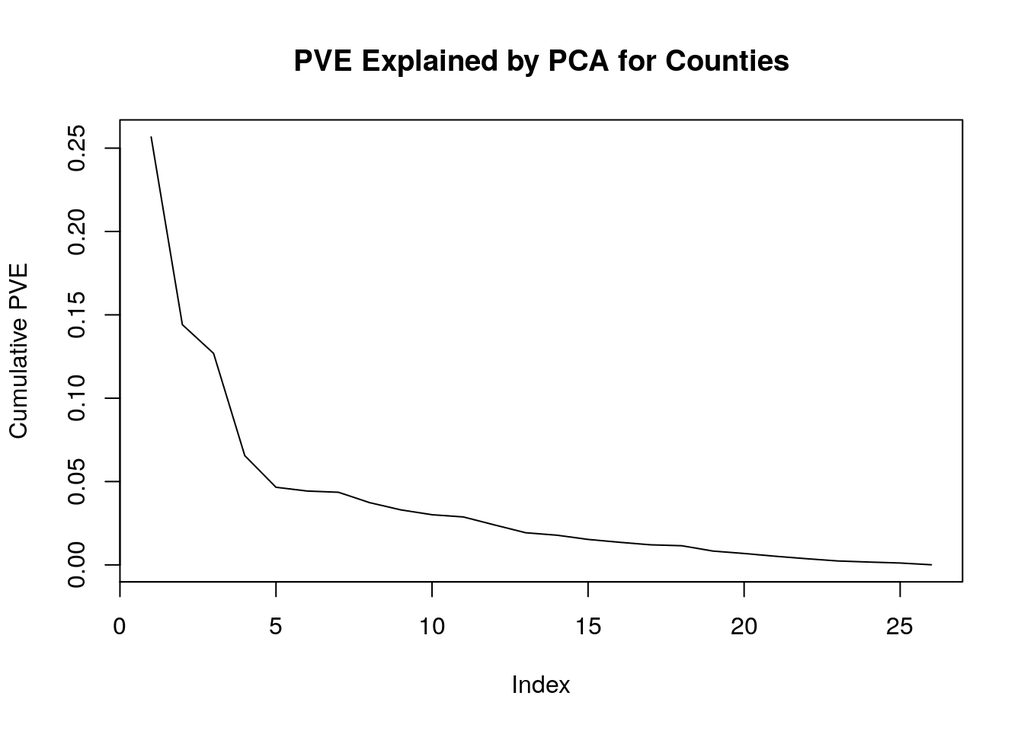

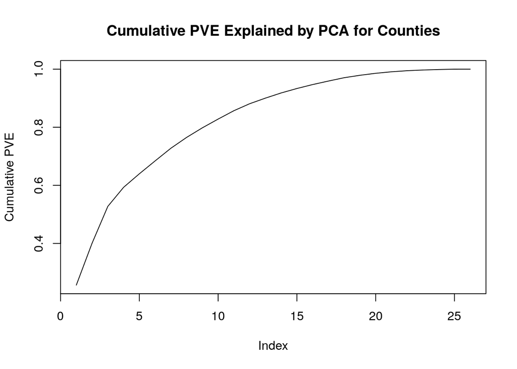

```
## [1] 13
```

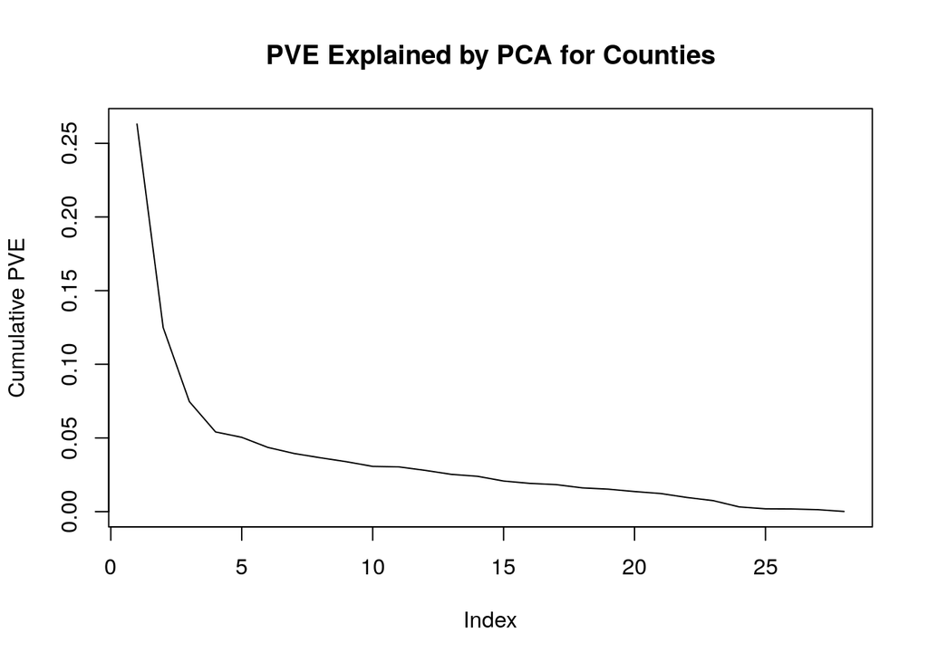

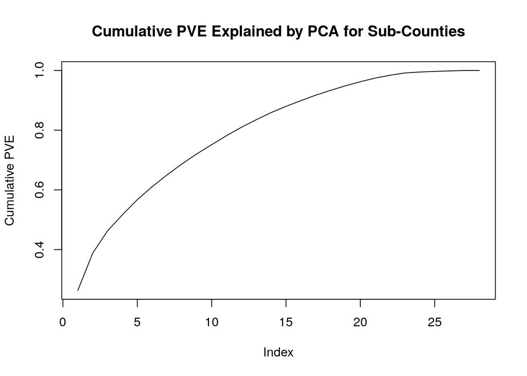

```
## [1] 16
```

To capture 90% of the variance for both the county and sub-county, we need at least 13 principal components and 16 sub-county components.

# 15.

```
## census.hc10
##    1    2    3    4    5    6    7    8    9   10
## 2307  779   67    8   20    4    3    3   23    4
```

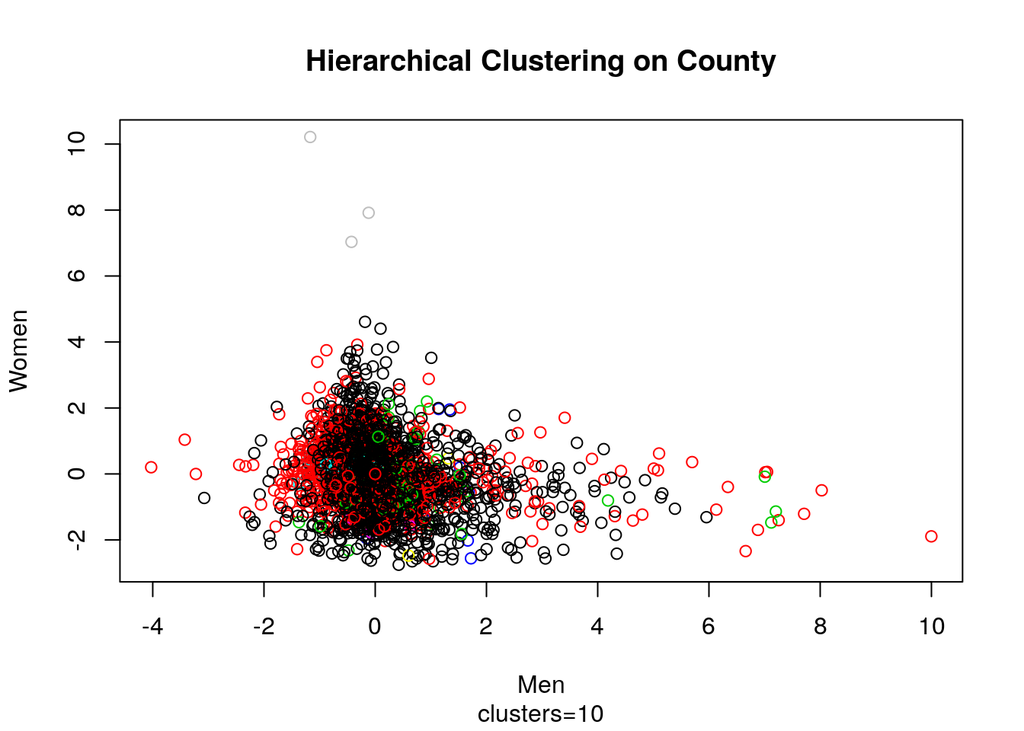

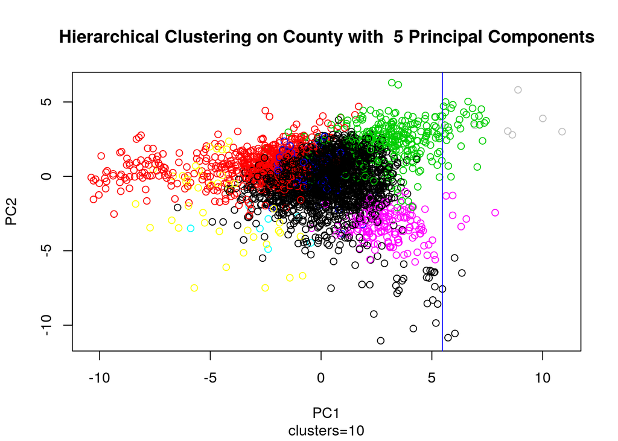

The blue line here indicates the location of San Mateo county in our scatter plot. We can see that the cluster it has been assigned to differs between the core component data and the PCA form of our data. At the same time however, in the PCA cluster graph we see that there is overlap with the cluster that San Mateo belongs to in the core component cluster. This difference in assignment can be attributed to the dimensionalty reduction caused by PCA. It is likely that the altering of distances slightly affected the San Mateo observation to be classified into a different cluster. However, the potential overlap tells us that the changes present from the transition were not extreme either.

# 16.

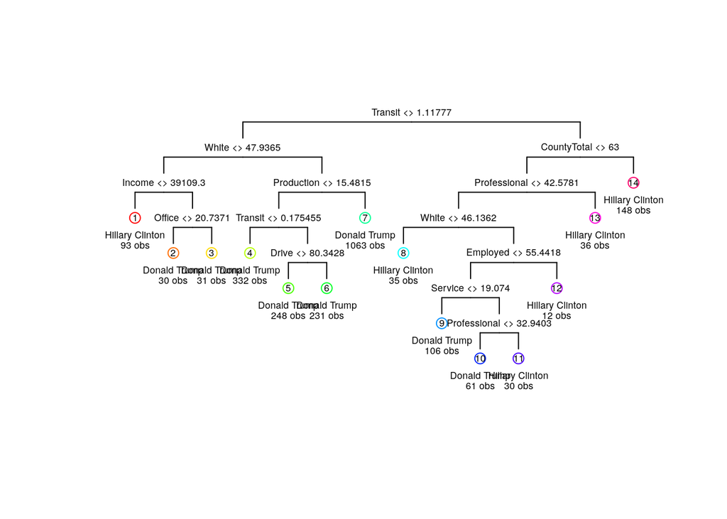

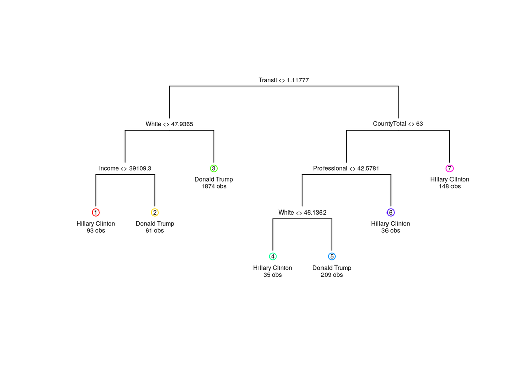

```
##          train.error test.error
## tree      0.06473941  0.0796748
## logistic          NA         NA
## lasso             NA         NA
```

# 17.

```
##
## Call:
## glm(formula = candidate ~ ., family = "binomial", data = trn.cl)
##
## Deviance Residuals:
##     Min       1Q   Median       3Q      Max
## -3.7636  -0.2675  -0.1165  -0.0445   3.6416
##
## Coefficients:
##                   Estimate Std. Error z value Pr(>|z|)
## (Intercept)     -1.641e+01  9.177e+00  -1.788  0.07376 .
## Men              5.009e-02  5.104e-02   0.981  0.32637
## Women            9.738e-05  1.672e-04   0.582  0.56027
## White           -2.070e-01  6.451e-02  -3.209  0.00133 **
## Citizen          1.289e-01  2.963e-02   4.351 1.35e-05 ***
## Minority        -7.391e-02  6.205e-02  -1.191  0.23357
## Income          -4.476e-05  2.644e-05  -1.693  0.09046 .
## IncomeErr       -1.551e-05  6.151e-05  -0.252  0.80094
## IncomePerCap     1.930e-04  6.294e-05   3.065  0.00217 **
## IncomePerCapErr -1.942e-04  1.369e-04  -1.418  0.15614
## Poverty          4.794e-02  4.051e-02   1.183  0.23671
## ChildPoverty    -1.437e-02  2.506e-02  -0.573  0.56632
## Professional     2.442e-01  3.799e-02   6.428 1.29e-10 ***
## Service          3.074e-01  4.670e-02   6.583 4.61e-11 ***
## Office           8.866e-02  4.674e-02   1.897  0.05784 .
## Production       1.592e-01  4.161e-02   3.827  0.00013 ***
## Drive           -1.894e-01  4.493e-02  -4.216 2.49e-05 ***
## Carpool         -1.634e-01  5.965e-02  -2.740  0.00614 **
## Transit          6.697e-02  8.974e-02   0.746  0.45554
## OtherTransp     -7.985e-02  9.309e-02  -0.858  0.39104
## WorkAtHome      -1.138e-01  7.210e-02  -1.578  0.11462
## MeanCommute      3.004e-02  2.450e-02   1.226  0.22006
## Employed         1.593e-01  3.214e-02   4.955 7.23e-07 ***
## PrivateWork      9.065e-02  2.199e-02   4.123 3.74e-05 ***
## SelfEmployed     2.457e-02  4.669e-02   0.526  0.59872
## FamilyWork      -1.026e+00  3.949e-01  -2.599  0.00936 **
## Unemployment     1.567e-01  3.762e-02   4.165 3.12e-05 ***
## CountyTotal      1.448e-03  1.800e-03   0.804  0.42117
## ---
## Signif. codes:  0 '***' 0.001 '**' 0.01 '*' 0.05 '.' 0.1 ' ' 1
##
## (Dispersion parameter for binomial family taken to be 1)
##
##     Null deviance: 2078.43  on 2455  degrees of freedom
## Residual deviance:  866.74  on 2428  degrees of freedom
## AIC: 922.74
##
## Number of Fisher Scoring iterations: 7
```

```
##          train.error test.error
## tree      0.06473941 0.07967480
## logistic  0.06596091 0.08130081
## lasso             NA         NA
```

# 18.

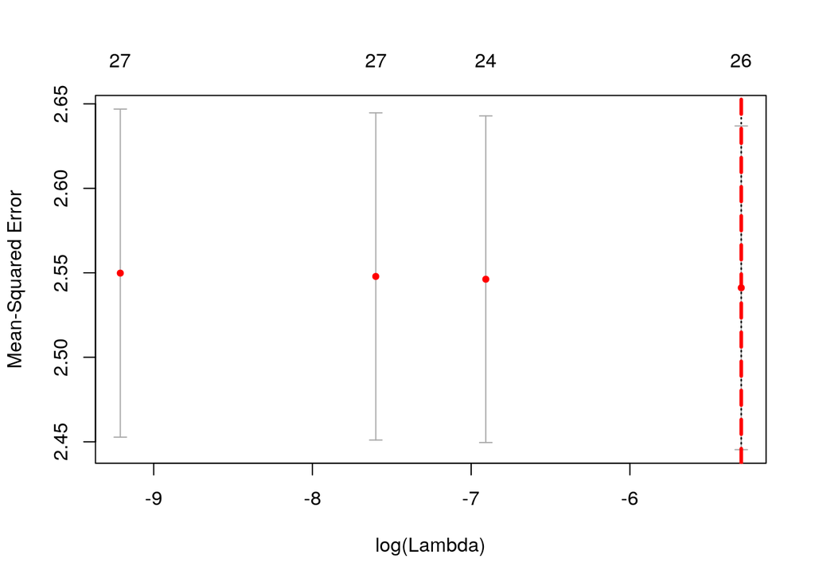

```
## [1] 0.005
```

No-Tuning Parameter

|  | x |
| --- | --- |
| (Intercept) | -2.6017559 |
| Men | -0.0199799 |
| Women | -0.0000823 |
| White | -0.0524712 |
| Citizen | 0.0504396 |
| Minority | 0.0020394 |
| Income | 0.0000128 |
| IncomeErr | -0.0000128 |
| IncomePerCap | 0.0000462 |
| IncomePerCapErr | -0.0000193 |
| Poverty | 0.1038301 |
| ChildPoverty | -0.0243561 |
| Professional | 0.1043815 |
| Service | 0.1006387 |
| Office | 0.0288542 |
| Production | 0.0591313 |
| Drive | -0.0360183 |
| Carpool | -0.0208540 |
| Transit | -0.0280882 |
| OtherTransp | 0.0527793 |
| WorkAtHome | -0.0169649 |
| MeanCommute | 0.0285066 |
| Employed | 0.0772345 |
| PrivateWork | 0.0142741 |
| SelfEmployed | -0.0074870 |
| FamilyWork | -0.0453547 |
| Unemployment | 0.0724124 |
| CountyTotal | 0.0028853 |

```
##          train.error test.error
## tree      0.06473941 0.07967480
## logistic  0.06596091 0.08130081
## lasso     0.15513030 0.13658540
```

The optimal value of Lambda is 0.005.

# 19.

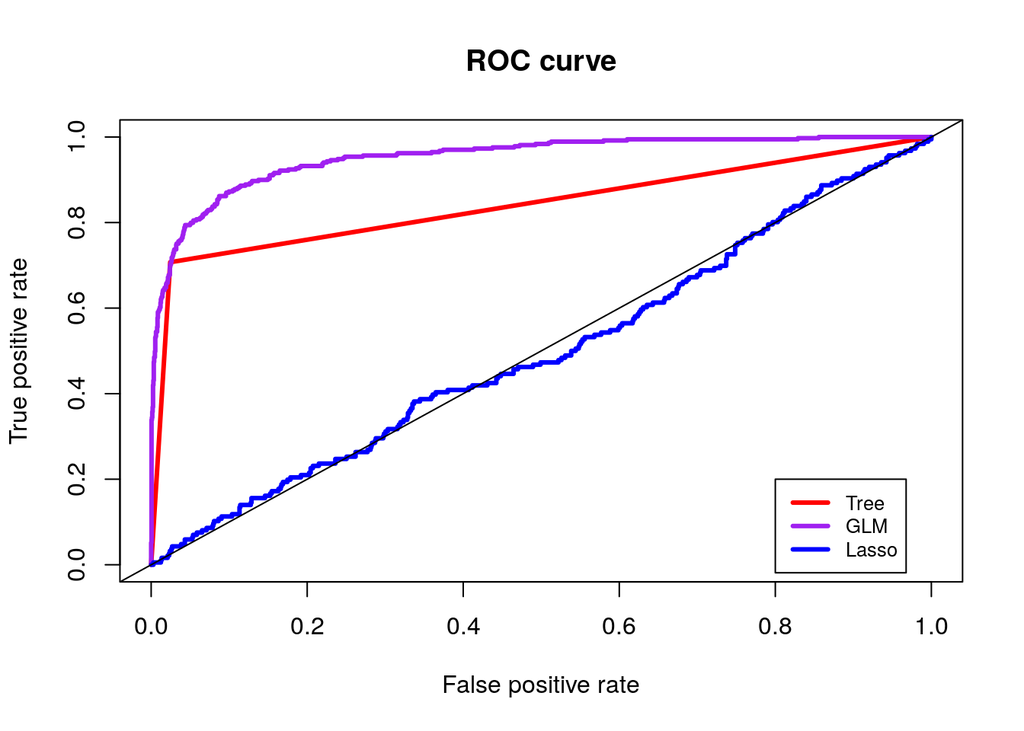

# 20.

# Exploring with KNN

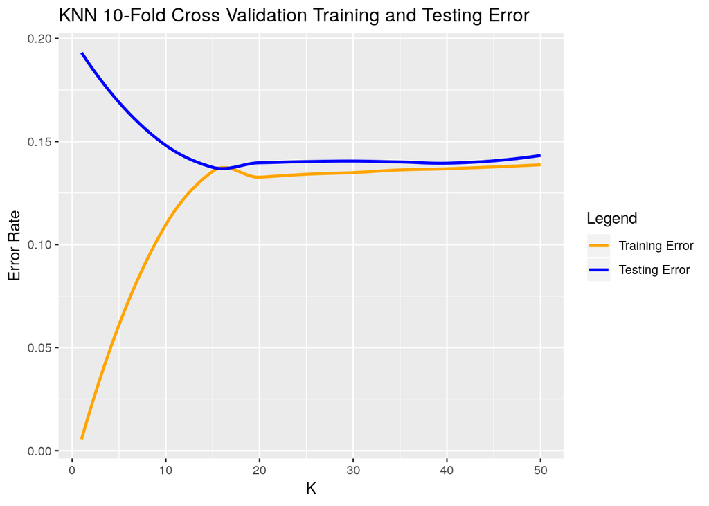